# PUTRI SALWA RAMADHANI_233210216_ARRAY DAN LIBRARY

NAMA : PUTRI SALWA RAMADHANI

NPM : 233210216

KELAS : 2 E

1. TUGAS ARRAY

```python
#perkalian matrix array

import numpy as np

A = np.array([[2,2],[1,0],[0,4]])
B = np.array([[9,1],[6,5],[0,5]])
C = np.array([[1,4],[7,0],[3,9]])

perkalian = A * B * C
print(perkalian)
```

```
[[ 18   8]
 [ 42   0]
 [  0 180]]
```

```python
#pengurangan matrix array

import numpy as np

A = np.array([[2,2],[1,0],[0,4]])
B = np.array([[9,1],[6,5],[0,5]])
C = np.array([[1,4],[7,0],[3,9]])

pengurangan = A - B - C
print(pengurangan)
```

```
[[ -8  -3]
 [-12  -5]
 [ -3 -10]]
```

```python
# Transpose Matrix

import numpy as np

A = np.array([[2,2],[1,0],[0,4]])
B = np.array([[9,1],[6,5],[0,5]])
C = np.array([[1,4],[7,0],[3,9]])

transpose_A = np.transpose(A)
transpose_B = np.transpose(B)
transpose_C = np.transpose(C)

print(transpose_A)
print(transpose_B)
print(transpose_C)
```

```
[[2 1 0]
 [2 0 4]]
[[9 6 0]
 [1 5 5]]
[[1 7 3]
 [4 0 9]]
```

```python
# Nilai Invers

import numpy as np

A = np.array([[2,2],[1,0]])
B = np.array([[9,1],[6,5]])
C = np.array([[1,4],[7,0]])

inverse_A = np.linalg.inv(A)
inverse_B = np.linalg.inv(B)
inverse_C = np.linalg.inv(C)

print("\nInvers matrix A:")
print("\nInvers matrix B:")
print("\nInvers matrix C:")
print(inverse_A)
print(inverse_B)
print(inverse_C)
```

```
Invers matrix A:

Invers matrix B:

Invers matrix C:
[[ 0.   1. ]
 [ 0.5 -1. ]]
[[ 0.12820513 -0.02564103]
 [-0.15384615  0.23076923]]
[[ 0.          0.14285714]
 [ 0.25       -0.03571429]]
```

```python
# Nilai Determinan

import numpy as np

A = np.array([[2,2],[1,0]])
B = np.array([[9,1],[6,5]])
C = np.array([[1,4],[7,0]])

determinant_A = np.linalg.det(A)
determinant_B = np.linalg.det(B)
determinant_C = np.linalg.det(C)
print("Determinan dari matrix A:", determinant_A)
print("Determinan dari matrix B:", determinant_B)
print("Determinan dari matrix C:", determinant_C)
```

```
Determinan dari matrix A: -2.0
Determinan dari matrix B: 38.99999999999999
Determinan dari matrix C: -27.999999999999996
```

2. TUGAS LIBRARY

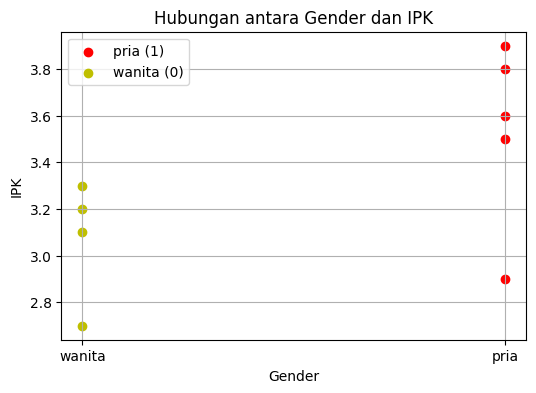

```python
import matplotlib.pyplot as plt

# Data
usia = [20, 22, 21, 23, 20, 22, 21, 24, 23]
ipk = [3.5, 3.2, 3.8, 2.9, 3.1, 3.6, 2.7, 3.9, 3.3]
gender = [1, 0, 1, 1, 0, 1, 0, 1, 0]  # 1 for pria, 0 for wanita

plt.figure(figsize=(6, 4))

# Filtering IPK based on gender
pria = [ipk[i] for i in range(len(gender)) if gender[i] == 1]
wanita = [ipk[i] for i in range(len(gender)) if gender[i] == 0]

# Plotting scatter plot
plt.scatter([1]*len(pria), pria, color='r', label='pria (1)')
plt.scatter([0]*len(wanita), wanita, color='y', label='wanita (0)')

# Visualisasi
plt.xlabel('Gender')
plt.ylabel('IPK')
plt.title('Hubungan antara Gender dan IPK')
plt.legend()
plt.xticks([0, 1], ['wanita', 'pria'])
plt.grid(True)
plt.show()
```

PENJELASAN CODING

1. matplotlib.pyplot as plt, yang digunakan untuk membuat berbagai jenis plot dan grafik.

# Data ini mendefinisikan tiga daftar (list) yaitu usia, ipk, dan gender. Daftar usia berisi usia individu, daftar ipk berisi nilai IPK masing-masing individu, dan daftar gender berisi informasi gender (1 untuk pria dan 0 untuk wanita).

3. plt.figure(figsize=(6, 4)) ini membuat sebuah figure (gambar) dengan ukuran 6x4 inci menggunakan plt.figure.